# 201.8. SSSource table

For the Rubin Science Platform at data.lsst.cloud.  
Data Release: [Data Preview 1](https://dp1.lsst.io/)  
Container Size: large  
LSST Science Pipelines version: r29.2.0  
Last verified to run: 2025-09-02  
Repository: github.com/lsst/tutorial-notebooks

**Learning objective:** To understand the contents of the `SSSource` table and how to access it.

**LSST data products:** `SSSource`

**Packages:** `lsst.rsp`, `lsst.daf.butler`

**Credit:** Originally developed by the Rubin Community Science team. Please consider acknowledging them if this notebook is used for the preparation of journal articles, software releases, or other notebooks.

**Get Support:** Everyone is encouraged to ask questions or raise issues in the [Support Category](https://community.lsst.org/c/support) of the Rubin Community Forum. Rubin staff will respond to all questions posted there.

## 1. Introduction

The `SSSource` table contains single-epoch solar system source information corresponding to a specific difference image detection.

- TAP table name: `dp1.SSSource`
- butler table name: `ss_source`
- columns: 23
- rows: 5,988

**Related tutorials:** The TAP and butler data access services are demonstrated in the 100-level "How to" tutorials.

### 1.1. Import packages

Import standard python packages `numpy`, `matplotlib` and `astropy`.

From the `lsst` package, import modules for the TAP service, the butler, and plotting.

```python
import numpy as np
import matplotlib.pyplot as plt
from lsst.rsp import get_tap_service
from lsst.daf.butler import Butler
from lsst.utils.plotting import (get_multiband_plot_colors,
                                 get_multiband_plot_symbols)
```

### 1.2. Define parameters and functions

Create an instance of the TAP service, and assert that it exists.

```python
service = get_tap_service("tap")
assert service is not None
```

Create an instance of the Rubin data butler, and assert that it exists.

```python
butler = Butler('dp1', collections="LSSTComCam/DP1")
assert butler is not None
```

Define the colors and symbols to represent the LSST filters in plots.

```python
filter_names = ['u', 'g', 'r', 'i', 'z', 'y']
filter_colors = get_multiband_plot_colors()
filter_symbols = get_multiband_plot_symbols()
```

## 2. Schema (columns)

To browse the table schema visit the [Rubin schema browser](https://sdm-schemas.lsst.io/), or use the TAP service via the Portal Aspect or as demonstrated in Section 2.1.

### 2.1. Retrieve table schema

To retrieve the table schema, define a query for the schema columns of the `SSSource` table and run the query job.

```python
query = "SELECT column_name, datatype, description, unit " \
        "FROM tap_schema.columns " \
        "WHERE table_name = 'dp1.SSSource'"
job = service.submit_job(query)
job.run()
job.wait(phases=['COMPLETED', 'ERROR'])
print('Job phase is', job.phase)
if job.phase == 'ERROR':
    job.raise_if_error()
```

```
Job phase is COMPLETED
```

Retrieve the query results and display them as an `astropy` table with the `to_table()` attribute.

```python
assert job.phase == 'COMPLETED'
results = job.fetch_result().to_table()
results
```

*Table length=23*

| column_name str64 | datatype str64 | description str512 | unit str64 |
| --- | --- | --- | --- |
| diaSourceId | long | Unique identifier of the observation |  |
| eclipticBeta | double | Ecliptic latitude | deg |
| eclipticLambda | double | Ecliptic longitude | deg |
| galacticB | double | Galactic latitute | deg |
| galacticL | double | Galactic longitude | deg |
| heliocentricDist | float | Heliocentric distance | AU |
| heliocentricVX | float | Cartesian heliocentric X velocity (at the emit time) | AU |
| heliocentricVY | float | Cartesian heliocentric Y velocity (at the emit time) | AU |
| heliocentricVZ | float | Cartesian heliocentric Z velocity (at the emit time) | AU |
| heliocentricX | float | Cartesian heliocentric X coordinate (at the emit time) | AU |
| heliocentricY | float | Cartesian heliocentric Y coordinate (at the emit time) | AU |
| heliocentricZ | float | Cartesian heliocentric Z coordinate (at the emit time) | AU |
| phaseAngle | float | Phase angle | deg |
| residualDec | double | Residual Dec vs. ephemeris | deg |
| residualRa | double | Residual R.A. vs. ephemeris | deg |
| ssObjectId | long | Unique identifier of the object. |  |
| topocentricDist | float | Topocentric distace | AU |
| topocentricVX | float | Cartesian topocentric X velocity (at the emit time) | AU |
| topocentricVY | float | Cartesian topocentric Y velocity (at the emit time) | AU |
| topocentricVZ | float | Cartesian topocentric Z velocity (at the emit time) | AU |
| topocentricX | float | Cartesian topocentric X coordinate (at the emit time) | AU |
| topocentricY | float | Cartesian topocentric Y coordinate (at the emit time) | AU |
| topocentricZ | float | Cartesian topocentric Z coordinate (at the emit time) | AU |

Option to print every column name as a list.

```python
# for col in results['column_name']:
#     print(col)
```

Delete the job, but not the `results`.

```python
del query
job.delete()
```

### 2.2. Key columns

Of the 23 columns of the `SSSource` table, several are the most commonly used.

#### 2.2.1. Solar System object Id

The long integer that uniquely identifies each Solar System object.

- `ssObjectId`

#### 2.2.2. Heliocentric distance

The cartesian heliocentric position and velocity coordinates:

- `heliocentricX`, `heliocentricY`, `heliocentricZ`, `heliocentricVX`, `heliocentricVY`, `heliocentricVZ`

The heliocentric distance:

- `heliocentricDist`

#### 2.2.3. Topocentric distance

The topocentric position and velocity coordinates:

- `topocentricX`, `topocentricY`, `topocentricZ`, `topocentricVX`, `topocentricVY`, `topocentricVZ`

The topocentric distance:

- `topocentricDist`

#### 2.2.4. Phase angle

The phase angle is the angle between the light incident onto an observed object and the light reflected from the object.

- `phaseAngle`

### 2.3. Descriptions and units

For a subset of the key columns show the table of their descriptions and units.

```python
col_list = set(['ssObjectId', 'heliocentricDist', 'topocentricDist', 'phaseAngle'])
tx = [i for i, item in enumerate(results['column_name']) if item in col_list]
results[tx]
```

*Table length=4*

| column_name str64 | datatype str64 | description str512 | unit str64 |
| --- | --- | --- | --- |
| heliocentricDist | float | Heliocentric distance | AU |
| phaseAngle | float | Phase angle | deg |
| ssObjectId | long | Unique identifier of the object. |  |
| topocentricDist | float | Topocentric distace | AU |

Clean up.

```python
del col_list, tx, results
```

## 3. Data access

The `SSSource` table is available via the TAP service and the butler.

**Recommended access method:** TAP.

### 3.1. TAP (Table Access Protocol)

The `SSSource` table is stored in Qserv and accessible via the TAP services using ADQL queries.

#### 3.1.1. Demo query

Define a query to return the four of the "key columns" from Section 2.3.

```python
query = "SELECT ssObjectId, heliocentricDist, topocentricDist, phaseAngle "\
        "FROM dp1.SSSource " \
        "ORDER BY ssObjectId ASC "
job = service.submit_job(query)
job.run()
job.wait(phases=['COMPLETED', 'ERROR'])
print('Job phase is', job.phase)
if job.phase == 'ERROR':
    job.raise_if_error()
```

```
Job phase is COMPLETED
```

Fetch the results as an `astropy` table.

```python
assert job.phase == 'COMPLETED'
results = job.fetch_result().to_table()
print(len(results))
```

```
5988
```

Option to display the table.

```python
# results
```

Check if any SS objects had more than one SS source detected (with the option to print the results).

```python
values, counts = np.unique(results['ssObjectId'], return_counts=True)
tx = np.where(counts > 1)[0]
print('Solar System objects with >1 detection: ', len(tx))
# for x in tx:
#    print('ssObjectId: ', values[x], '  number of sources', counts[x])
```

```
Solar System objects with >1 detection:  417
```

As an example, plot a histogram of the number of sources for each object.

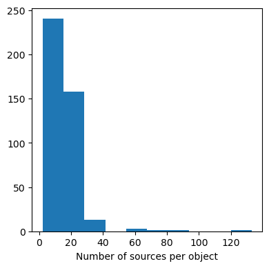

```python
fig, ax = plt.subplots(figsize=(4, 4))
ax.hist(counts[tx])
plt.xlabel('Number of sources per object')
plt.tight_layout()
plt.show()
```

> **Figure 1:** Histogram of the number of source detections for every Solar System object with more than one detection.

Clean up.

```python
job.delete()
del query, results, values, counts, tx
```

#### 3.1.2. Joinable tables

The `DiaSource` table contains information about the astrometric and photometric measurements for solar system objects detected in difference images.

```python
query = "SELECT sss.ssObjectId, sss.heliocentricDist, "\
        "sss.topocentricDist, sss.phaseAngle, "\
        "dia.midpointMjdTai, dia.band "\
        "FROM dp1.SSSource AS sss " \
        "JOIN dp1.DiaSource AS dia ON sss.diaSourceId = dia.diaSourceId " \
        "WHERE dia.ssObjectId > 0"
job = service.submit_job(query)
job.run()
job.wait(phases=['COMPLETED', 'ERROR'])
print('Job phase is', job.phase)
if job.phase == 'ERROR':
    job.raise_if_error()
```

```
Job phase is COMPLETED
```

Fetch the results as an `astropy` table.

```python
assert job.phase == 'COMPLETED'
results = job.fetch_result().to_table()
print(len(results))
```

```
5988
```

Plot topocentric distance as a function of the observation midpoint of every Solar System source.

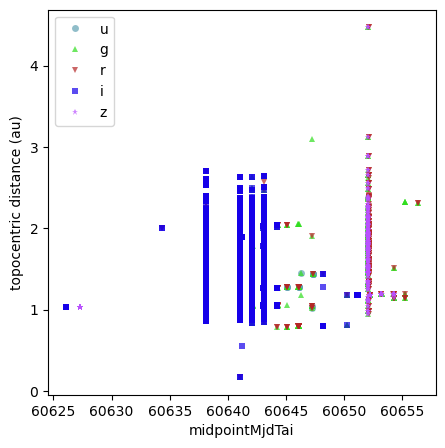

```python
fig, ax = plt.subplots(figsize=(5, 5))
for filt in filter_names:
    fx = np.where(results['band'] == filt)[0]
    if len(fx) > 0:
        ax.plot(results['midpointMjdTai'][fx],
                results['topocentricDist'][fx],
                filter_symbols[filt], ms=5, mew=0, alpha=0.7,
                color=filter_colors[filt], label=filt)
plt.xlabel('midpointMjdTai')
plt.ylabel('topocentric distance (au)')
plt.legend(loc='upper left')
plt.show()
```

> **Figure 2:** Topocentric distance as a function of the observation midpoint for every Solar System source, with colors and symbols to represent the five filters (ugriz) obtained on the nights of MJD = 60625 - 60658. The topocentric distance of all `SSSources` is not expected to be correlated with observation date, but rather this plot shows the 5 nights that the Low Ecliptic Latitude field were observed are obvious from the many more detections on those nights.

Clean up.

```python
job.delete()
del query, results
```

### 3.2. Butler

TAP is the recommended way to access the solar system source table, but the butler can be used to retrieve the same table information.

Show that the `ss_source` table has no dimensions. For DP1, it can only be retrieved from the butler in full.

```python
butler.get_dataset_type('ss_source')
```

```
DatasetType('ss_source', {}, ArrowAstropy)
```

```python
butler.get_dataset_type('ss_source').dimensions.required
```

```
{}
```

#### 3.2.1. Demo query

Define the columns to retrieve.

```python
col_list = ['ssObjectId', 'heliocentricDist', 'topocentricDist', 'phaseAngle']
```

Get the data from the butler.

```python
results = butler.get('ss_source', parameters={'columns': col_list})
print(len(results))
```

```
5988
```

Option to display the results.

```python
# results
```

Plot phase angle as a function of heliocentric distance for every Solar System source.

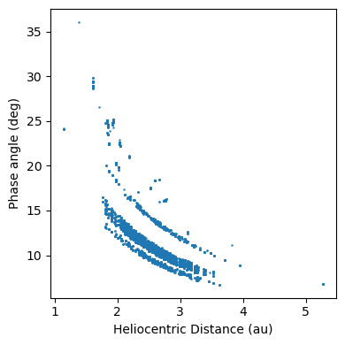

```python
fig, ax = plt.subplots(figsize=(4, 4))

ax.scatter(results['heliocentricDist'], results['phaseAngle'], s=0.5)

plt.xlabel('Heliocentric Distance (au)')
plt.ylabel('Phase angle (deg)')
plt.tight_layout()

plt.show()
```

> **Figure 3:** Phase angle as a function of heliocentric distance for every Solar System source.

Clean up.

```python
del col_list, results
```